# Computer Assignment 5 - Phase 2

Danial Saeedi(810198571)

# Importing dependencies

```python
import numpy as np
from tensorflow.keras import *
import matplotlib.pyplot as plt
from sklearn.metrics import classification_report
import pandas as pd
import warnings
warnings.filterwarnings('ignore')
```

# Importing the dataset

```python
! pip install -q kaggle
```

```python
! mkdir ~/.kaggle
```

```python
cp kaggle.json ~/.kaggle/
```

```python
! chmod 600 ~/.kaggle/kaggle.json
```

```python
!kaggle datasets download -d sachinpatel21/az-handwritten-alphabets-in-csv-format
```

```
Downloading az-handwritten-alphabets-in-csv-format.zip to /content
 94% 173M/185M [00:04<00:00, 56.7MB/s]
100% 185M/185M [00:04<00:00, 38.7MB/s]
```

```python
!unzip az-handwritten-alphabets-in-csv-format.zip -d dataset/
```

```
Archive:  az-handwritten-alphabets-in-csv-format.zip
  inflating: dataset/A_Z Handwritten Data.csv
  inflating: dataset/A_Z Handwritten Data/A_Z Handwritten Data.csv
```

```python
df = pd.read_csv('dataset/A_Z Handwritten Data.csv')
```

# Phase 1: Data pre-processing

**Why one hot encoding is useful here?**

One hot encoding makes our training data more useful and expressive, and it can be rescaled easily. By using numeric values, we more easily determine a probability for our values. In particular, one hot encoding is used for our output values, since it provides more nuanced predictions than single labels.

By using one hot encoding technique, the shape of each row would be (1*26). And our output layer has 26 neurons as well.

```python
y = pd.get_dummies(df['0'], columns=['0'])
X = df.drop('0',axis=1)

y = y.values
X = X.values.reshape(-1,28,28)
```

```python
X.shape
```

```
(372450, 28, 28)
```

```python
len(y)
```

```
372450
```

```python
freqOfClasses = {'0': 0, '1': 0, '2': 0, '3': 0, '4': 0,'5': 0, '6': 0, '7': 0, '8': 0, '9': 0,'10':0,'11':0,'12':0,'13':0
                     ,'14':0,'15':0,'16':0,'17':0,'18':0,'19':0,'20':0,'21':0,'22':0,'23':0,'24':0,'25':0}
for label in df['0']:
    freqOfClasses[str(label)] += 1
```

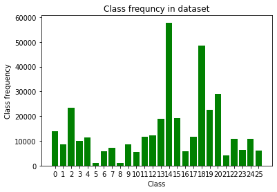

```python
plt.bar(freqOfClasses.keys(), freqOfClasses.values(), color='g')
plt.xlabel("Class")
plt.ylabel("Class frequency")
plt.title("Class frequncy in dataset")
plt.show()
```

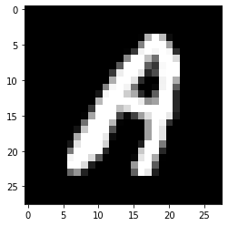

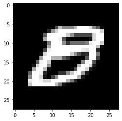

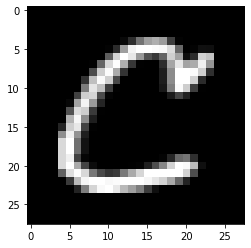

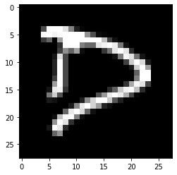

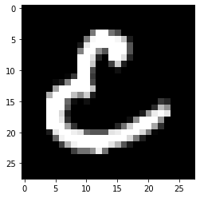

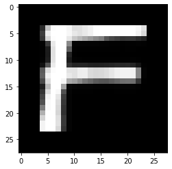

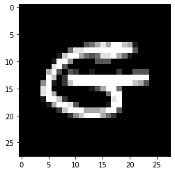

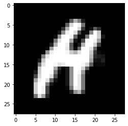

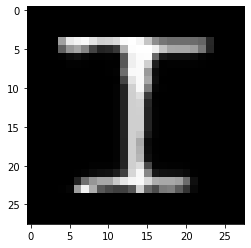

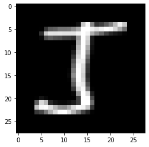

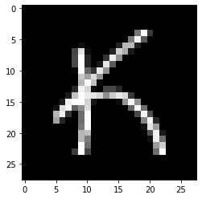

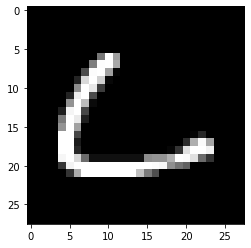

[14 more figures not shown]

```python
selectedFromClass = [False]*26
indexes = [0]*26
i = 0
for label in y.argmax(axis = 1):
    if selectedFromClass[int(label)] == False:
        selectedFromClass[int(label)] = True
        indexes[int(label)] = i
    if selectedFromClass == [True]*26:
        break
    i += 1

number = 0;
for index in indexes:
    new_array = np.reshape(X[index], (28, 28))
    plt.imshow(new_array,cmap="gray")
    plt.show()

    number += 1
```

```python
from sklearn.model_selection import train_test_split
X_train, X_test, y_train, y_test = train_test_split(X, y, test_size=0.20, random_state=42)

X_train = np.array(X_train)
X_test = np.array(X_test)
y_train = np.array(y_train)
y_test = np.array(y_test)
```

```python
import gc
del [[X,y,df]]
gc.collect()
```

```
64
```

# Phase 2

```python
import keras
from keras.models import Sequential
from keras.layers import Dense,Input,Flatten
import tensorflow as tf
```

```python
from keras import backend as K
def Recall(y_true, y_pred):
    true_positives = K.sum(K.round(K.clip(y_true * y_pred, 0, 1)))
    possible_positives = K.sum(K.round(K.clip(y_true, 0, 1)))
    recall = true_positives / (possible_positives + K.epsilon())
    return recall

def Precision(y_true, y_pred):
    true_positives = K.sum(K.round(K.clip(y_true * y_pred, 0, 1)))
    predicted_positives = K.sum(K.round(K.clip(y_pred, 0, 1)))
    precision = true_positives / (predicted_positives + K.epsilon())
    return precision

def F1(y_true, y_pred):
    precision = Precision(y_true, y_pred)
    recall = Recall(y_true, y_pred)
    return 2*((precision*recall)/(precision+recall+K.epsilon()))
```

```python
model = Sequential()
model.add(Input(shape=(28, 28, 1)))
model.add(Flatten())
model.add(Dense(50, activation='relu'))
model.add(Dense(40, activation='relu'))
model.add(Dense(30, activation='relu'))
model.add(Dense(26, activation='softmax'))
```

```python
opt = tf.keras.optimizers.SGD(learning_rate=0.01)
model.compile(loss='categorical_crossentropy', optimizer=opt, metrics=['accuracy', Recall, Precision, F1])
```

First of all we can see the name of layers. But about parameter what are they?

It shows the number of total weights and biases. For example we can see for first Dense layer we have 39250 which is number of weights:

$50(number of neurons) * 784(number of layer input) = 39200$

, plus number of biases which is 50.

So total will be: 39250.

```python
model.summary()
```

```
Model: "sequential"
_________________________________________________________________
 Layer (type)                Output Shape              Param #
=================================================================
 flatten (Flatten)           (None, 784)               0

 dense (Dense)               (None, 50)                39250

 dense_1 (Dense)             (None, 40)                2040

 dense_2 (Dense)             (None, 30)                1230

 dense_3 (Dense)             (None, 26)                806

=================================================================
Total params: 43,326
Trainable params: 43,326
Non-trainable params: 0
_________________________________________________________________
```

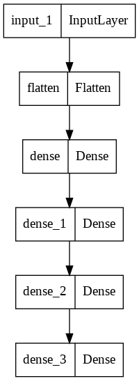

```python
utils.plot_model(model)
```

```python
# X_train = X_train.reshape(-1,28,28)
# history = model.fit(X_train, y_train, epochs=10, batch_size=32)
```

# Phase 3: Classification

## What is momentum in neural networks?

Momentum is a method which helps us to accelerate gradient vectors in the right directions. Momentum is an average of gradients that changes during the time and we use it to update weight in each step. Therefore, it leads to faster convergence. It is mostly used in neural networks considering the size of data in NNs makes a considerable time difference while training gradients. It can be used to handle noisy gradients. Moreover, it can handle extremely small gradients.

## Is it always good to set momentum to a larger number?

Momentum is a method which helps us to accelerate gradient In fact, momentum makes each step of the learning process dependent on its previous. If we set momentum and learning rate to large values, we will have bigger steps, and based on the dependency that we mentioned above, the next steps will be larger and larger. As a result, weights won't be updated in a correct way, and they will never reach optimal values. Therefore, large momentum does not necessarily lead to higher accuracies.

## Normalizing the data

```python
X_train = X_train/255
```

## Training the model

```python
history = model.fit(X_train, y_train, epochs=10, batch_size=32,validation_data=(X_test, y_test))
```

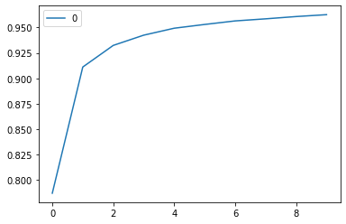

```python
model_loss = pd.DataFrame(history.history['accuracy'])
model_loss.plot()
```

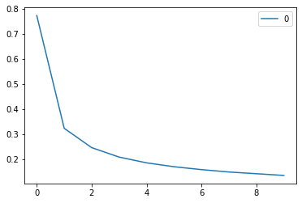

```python
model_loss = pd.DataFrame(history.history['loss'])
model_loss.plot()
```

```python
y_pred = model.predict(X_test)
y_pred = y_pred.argmax(axis = 1)
print(classification_report(y_test.argmax(axis = 1),y_pred))
```

```
              precision    recall  f1-score   support

           0       0.95      0.93      0.94      2806
           1       0.90      0.86      0.88      1673
           2       0.94      0.98      0.96      4742
           3       0.96      0.68      0.80      2044
           4       0.76      0.97      0.85      2214
           5       0.79      0.90      0.84       231
           6       0.93      0.79      0.85      1183
           7       0.93      0.89      0.91      1466
           8       0.93      0.81      0.86       237
           9       0.94      0.87      0.90      1668
          10       0.85      0.89      0.87      1132
          11       0.97      0.93      0.95      2319
          12       0.98      0.92      0.95      2487
```

[output cut: 17 more lines]

```python
y_pred = model.predict(X_train)
y_pred = y_pred.argmax(axis = 1)
print(classification_report(y_train.argmax(axis = 1),y_pred))
```

```
              precision    recall  f1-score   support

           0       0.94      0.97      0.95     11063
           1       0.91      0.95      0.93      6995
           2       0.97      0.97      0.97     18667
           3       0.96      0.88      0.91      8090
           4       0.96      0.95      0.95      9226
           5       0.97      0.91      0.94       932
           6       0.92      0.93      0.92      4579
           7       0.90      0.94      0.92      5752
           8       0.95      0.84      0.89       883
           9       0.95      0.92      0.93      6825
          10       0.91      0.92      0.92      4471
          11       0.96      0.98      0.97      9267
          12       0.95      0.97      0.96      9849
```

[output cut: 17 more lines]

## Part 1)

### momentum = 0.5

```python
model = Sequential()
model.add(Input(shape=(28, 28, 1)))
model.add(Flatten())
model.add(Dense(50, activation='relu'))
model.add(Dense(40, activation='relu'))
model.add(Dense(30, activation='relu'))
model.add(Dense(26, activation='softmax'))
opt = tf.keras.optimizers.SGD(learning_rate=0.01,momentum=0.5)
model.compile(loss='categorical_crossentropy', optimizer=opt, metrics=['accuracy', Recall, Precision, F1])
```

```python
history = model.fit(X_train, y_train, epochs=10, batch_size=32,validation_data=(X_test, y_test))
```

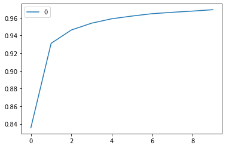

```python
model_loss = pd.DataFrame(history.history['accuracy'])
model_loss.plot()
```

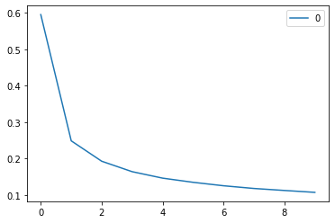

```python
model_loss = pd.DataFrame(history.history['loss'])
model_loss.plot()
```

```python
y_pred = model.predict(X_test)
y_pred = y_pred.argmax(axis = 1)
print(classification_report(y_test.argmax(axis = 1),y_pred))
```

```
              precision    recall  f1-score   support

           0       0.98      0.85      0.91      2806
           1       0.85      0.86      0.86      1673
           2       0.94      0.97      0.95      4742
           3       0.97      0.72      0.83      2044
           4       0.62      0.98      0.76      2214
           5       0.87      0.80      0.83       231
           6       0.93      0.77      0.84      1183
           7       0.82      0.93      0.87      1466
           8       0.91      0.86      0.89       237
           9       0.92      0.85      0.88      1668
          10       0.84      0.91      0.87      1132
          11       0.99      0.78      0.88      2319
          12       0.98      0.93      0.96      2487
```

[output cut: 17 more lines]

```python
y_pred = model.predict(X_train)
y_pred = y_pred.argmax(axis = 1)
print(classification_report(y_train.argmax(axis = 1),y_pred))
```

```
              precision    recall  f1-score   support

           0       0.98      0.96      0.97     11063
           1       0.93      0.97      0.95      6995
           2       0.97      0.98      0.98     18667
           3       0.96      0.90      0.93      8090
           4       0.96      0.96      0.96      9226
           5       0.97      0.91      0.94       932
           6       0.97      0.92      0.94      4579
           7       0.94      0.95      0.95      5752
           8       0.98      0.90      0.94       883
           9       0.97      0.94      0.95      6825
          10       0.95      0.93      0.94      4471
          11       0.99      0.96      0.98      9267
          12       0.96      0.98      0.97      9849
```

[output cut: 17 more lines]

## Momentum = 0.9

```python
model = Sequential()
model.add(Input(shape=(28, 28, 1)))
model.add(Flatten())
model.add(Dense(50, activation='relu'))
model.add(Dense(40, activation='relu'))
model.add(Dense(30, activation='relu'))
model.add(Dense(26, activation='softmax'))
opt = tf.keras.optimizers.SGD(learning_rate=0.01,momentum=0.9)
model.compile(loss='categorical_crossentropy', optimizer=opt, metrics=['accuracy', Recall, Precision, F1])
```

```python
history = model.fit(X_train, y_train, epochs=10, batch_size=32,validation_data=(X_test, y_test))
```

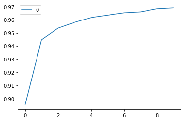

```python
model_loss = pd.DataFrame(history.history['accuracy'])
model_loss.plot()
```

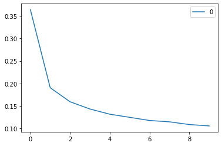

```python
model_loss = pd.DataFrame(history.history['loss'])
model_loss.plot()
```

```python
y_pred = model.predict(X_test)
y_pred = y_pred.argmax(axis = 1)
print(classification_report(y_test.argmax(axis = 1),y_pred))
```

```
              precision    recall  f1-score   support

           0       0.99      0.84      0.91      2806
           1       0.96      0.85      0.90      1673
           2       0.90      0.98      0.94      4742
           3       0.97      0.62      0.76      2044
           4       0.86      0.96      0.91      2214
           5       0.48      0.96      0.64       231
           6       0.82      0.89      0.86      1183
           7       0.86      0.89      0.88      1466
           8       0.73      0.95      0.82       237
           9       0.87      0.91      0.89      1668
          10       0.82      0.92      0.86      1132
          11       0.93      0.93      0.93      2319
          12       0.97      0.93      0.95      2487
```

[output cut: 17 more lines]

```python
y_pred = model.predict(X_train)
y_pred = y_pred.argmax(axis = 1)
print(classification_report(y_train.argmax(axis = 1),y_pred))
```

```
              precision    recall  f1-score   support

           0       0.98      0.93      0.96     11063
           1       0.94      0.97      0.96      6995
           2       0.97      0.98      0.98     18667
           3       0.92      0.96      0.94      8090
           4       0.99      0.92      0.95      9226
           5       0.94      0.95      0.95       932
           6       0.92      0.96      0.94      4579
           7       0.94      0.92      0.93      5752
           8       0.93      0.95      0.94       883
           9       0.94      0.96      0.95      6825
          10       0.86      0.96      0.91      4471
          11       0.96      0.98      0.97      9267
          12       0.97      0.98      0.97      9849
```

[output cut: 17 more lines]

## Momentum = 0.98

```python
model = Sequential()
model.add(Input(shape=(28, 28, 1)))
model.add(Flatten())
model.add(Dense(50, activation='relu'))
model.add(Dense(40, activation='relu'))
model.add(Dense(30, activation='relu'))
model.add(Dense(26, activation='softmax'))
opt = tf.keras.optimizers.SGD(learning_rate=0.01,momentum=0.98)
model.compile(loss='categorical_crossentropy', optimizer=opt, metrics=['accuracy', Recall, Precision, F1])
```

```python
history = model.fit(X_train, y_train, epochs=10, batch_size=32,validation_data=(X_test, y_test))
```

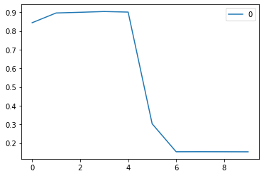

```python
model_loss = pd.DataFrame(history.history['accuracy'])
model_loss.plot()
```

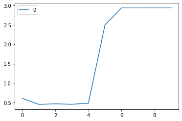

```python
model_loss = pd.DataFrame(history.history['loss'])
model_loss.plot()
```

```python
y_pred = model.predict(X_test)
y_pred = y_pred.argmax(axis = 1)
print(classification_report(y_test.argmax(axis = 1),y_pred))
```

```
              precision    recall  f1-score   support

           0       0.00      0.00      0.00      2806
           1       0.00      0.00      0.00      1673
           2       0.00      0.00      0.00      4742
           3       0.00      0.00      0.00      2044
           4       0.00      0.00      0.00      2214
           5       0.00      0.00      0.00       231
           6       0.00      0.00      0.00      1183
           7       0.00      0.00      0.00      1466
           8       0.00      0.00      0.00       237
           9       0.00      0.00      0.00      1668
          10       0.00      0.00      0.00      1132
          11       0.00      0.00      0.00      2319
          12       0.00      0.00      0.00      2487
```

[output cut: 17 more lines]

```python
y_pred = model.predict(X_train)
y_pred = y_pred.argmax(axis = 1)
print(classification_report(y_train.argmax(axis = 1),y_pred))
```

```
              precision    recall  f1-score   support

           0       0.00      0.00      0.00     11063
           1       0.00      0.00      0.00      6995
           2       0.00      0.00      0.00     18667
           3       0.00      0.00      0.00      8090
           4       0.00      0.00      0.00      9226
           5       0.00      0.00      0.00       932
           6       0.00      0.00      0.00      4579
           7       0.00      0.00      0.00      5752
           8       0.00      0.00      0.00       883
           9       0.00      0.00      0.00      6825
          10       0.00      0.00      0.00      4471
          11       0.00      0.00      0.00      9267
          12       0.00      0.00      0.00      9849
```

[output cut: 17 more lines]

## Analyzing the results

As you can see, increasing momentum lead to quicker convergence and better performance as well. But increasing it too much(momentum = 0.98) led to instability.

## Adam Optimizer

By using `Adam` optimier, the overall F1-Score increased by 2% compared to `SGD`.

```python
model = Sequential()
model.add(Input(shape=(28, 28, 1)))
model.add(Flatten())
model.add(Dense(50, activation='relu'))
model.add(Dense(40, activation='relu'))
model.add(Dense(30, activation='relu'))
model.add(Dense(26, activation='softmax'))
opt = tf.keras.optimizers.Adam()
model.compile(loss='categorical_crossentropy', optimizer=opt, metrics=['accuracy', Recall, Precision, F1])
```

```python
history = model.fit(X_train, y_train, epochs=10, batch_size=32,validation_data=(X_test, y_test))
```

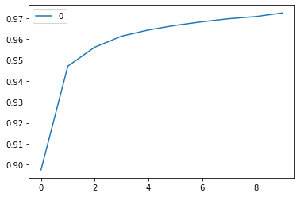

```python
model_loss = pd.DataFrame(history.history['accuracy'])
model_loss.plot()
```

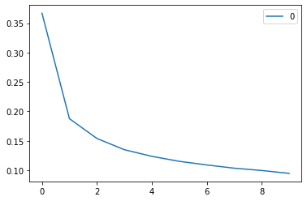

```python
model_loss = pd.DataFrame(history.history['loss'])
model_loss.plot()
```

```python
y_pred = model.predict(X_test)
y_pred = y_pred.argmax(axis = 1)
print(classification_report(y_test.argmax(axis = 1),y_pred))
```

```
              precision    recall  f1-score   support

           0       0.98      0.90      0.94      2806
           1       0.97      0.88      0.92      1673
           2       0.94      0.99      0.96      4742
           3       0.97      0.85      0.90      2044
           4       0.84      0.98      0.90      2214
           5       0.78      0.80      0.79       231
           6       0.94      0.87      0.91      1183
           7       0.88      0.93      0.90      1466
           8       0.93      0.89      0.91       237
           9       0.94      0.90      0.92      1668
          10       0.96      0.87      0.91      1132
          11       0.98      0.97      0.97      2319
          12       1.00      0.87      0.93      2487
```

[output cut: 17 more lines]

```python
y_pred = model.predict(X_train)
y_pred = y_pred.argmax(axis = 1)
print(classification_report(y_train.argmax(axis = 1),y_pred))
```

```
              precision    recall  f1-score   support

           0       0.98      0.96      0.97     11063
           1       0.96      0.97      0.96      6995
           2       0.98      0.98      0.98     18667
           3       0.90      0.97      0.94      8090
           4       0.98      0.95      0.97      9226
           5       0.96      0.88      0.92       932
           6       0.95      0.95      0.95      4579
           7       0.95      0.94      0.94      5752
           8       0.98      0.89      0.94       883
           9       0.98      0.93      0.95      6825
          10       0.97      0.92      0.95      4471
          11       0.99      0.98      0.98      9267
          12       0.97      0.98      0.97      9849
```

[output cut: 17 more lines]

## Part 2) Train the model for 20 epochs

### Why to use more than one epoch?

Passing the entire dataset through a neural network is not enough. And we need to pass the full dataset multiple times to the same neural network. But keep in mind that we are using a limited dataset and to optimise the learning and the graph we are using Gradient Descent which is an iterative process. So, updating the weights with single pass or one epoch is not enough.

One epoch leads to **underfitting**.

As we mentioned it is not necessary to use more than one epoch, because maybe we have a large enough dataset to train which does not happen so much in reality.

As the number of epochs increases, more number of times the weight are changed in the neural network and the curve goes from underfitting to optimal to overfitting curve.

### Is always increasing the epochs of training lead to better performance?

**No**. Because if we choose the number of epochs too high, it'll result in **overfitting**. So we have to be careful in choosing the correct amount of epochs.

Here's a couple of ways to handle this:

- We need to come-up with a simple model with less number of parameters to learn
- Add more data by augmentation
- Add noise to dense or convolution layers
- Add drop-out layers
- Add l1 or l2 regularizers
- Add early stopping
- Check the model accuracy on validation data
- Early stopping will tell you appropriate epochs without overfitting the model

```python
model = Sequential()
model.add(Input(shape=(28, 28, 1)))
model.add(Flatten())
model.add(Dense(50, activation='relu'))
model.add(Dense(40, activation='relu'))
model.add(Dense(30, activation='relu'))
model.add(Dense(26, activation='softmax'))
opt = tf.keras.optimizers.Adam()
model.compile(loss='categorical_crossentropy', optimizer=opt, metrics=['accuracy', Recall, Precision, F1])
```

```python
history = model.fit(X_train, y_train, epochs=20, batch_size=32,validation_data=(X_test, y_test))
```

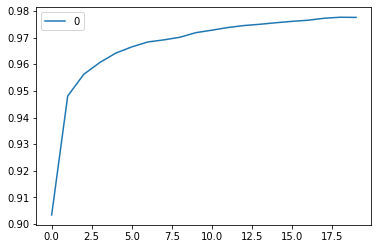

```python
model_loss = pd.DataFrame(history.history['accuracy'])
model_loss.plot()
```

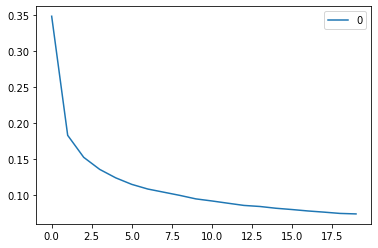

```python
model_loss = pd.DataFrame(history.history['loss'])
model_loss.plot()
```

```python
y_pred = model.predict(X_test)
y_pred = y_pred.argmax(axis = 1)
print(classification_report(y_test.argmax(axis = 1),y_pred))
```

```
              precision    recall  f1-score   support

           0       0.98      0.94      0.96      2806
           1       0.97      0.86      0.91      1673
           2       0.94      0.99      0.96      4742
           3       0.98      0.79      0.87      2044
           4       0.79      0.98      0.88      2214
           5       0.83      0.94      0.88       231
           6       0.94      0.79      0.86      1183
           7       0.87      0.94      0.90      1466
           8       0.85      0.92      0.89       237
           9       0.88      0.89      0.89      1668
          10       0.95      0.83      0.88      1132
          11       0.97      0.94      0.95      2319
          12       0.99      0.92      0.96      2487
```

[output cut: 17 more lines]

```python
y_pred = model.predict(X_train)
y_pred = y_pred.argmax(axis = 1)
print(classification_report(y_train.argmax(axis = 1),y_pred))
```

[output not shown]

## Part 3) use MSE as loss function

MSE performed much worse compared to Categorical Crossentropy.

### Why not to use MSE as loss function for classification?

As we see below, loss and accuracy does not change that much and also they does not have good values. So why this happens?

In the case of classification, we take the argmax of the probability of each training instance.

Now consider below example.

Our probability utputs are 0.49 and 0.51. So the class predicted is class 1. Now imagine that true label is also 1.

In such a case, if MSE is used, it will return 0 as a loss value, whereas the binary cross-entropy will return some "tangible" value. And, if somehow with all data samples, the trained model predicts a similar type of probability, then binary cross-entropy effectively return a big accumulative loss value, whereas MSE will return a 0.

MSE is usable in regresssion.

So we can see here MSE does not make enough Accuracy for us (And other metrics too).

The **Mean Squared Error** is usually used for regression problems not classification.

```python
model = Sequential()
model.add(Input(shape=(28, 28, 1)))
model.add(Flatten())
model.add(Dense(50, activation='relu'))
model.add(Dense(40, activation='relu'))
model.add(Dense(30, activation='relu'))
model.add(Dense(26, activation='softmax'))
opt = tf.keras.optimizers.Adam()
model.compile(loss='mean_squared_error', optimizer=opt, metrics=['accuracy', Recall, Precision, F1])
```

```python
history = model.fit(X_train, y_train, epochs=20, batch_size=32,validation_data=(X_test, y_test))
```

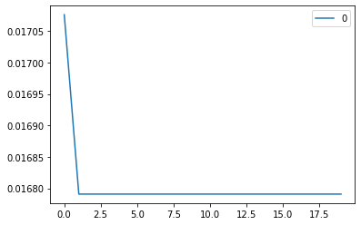

```python
model_loss = pd.DataFrame(history.history['accuracy'])
model_loss.plot()
```

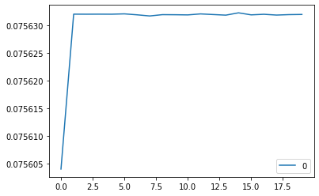

```python
model_loss = pd.DataFrame(history.history['loss'])
model_loss.plot()
```

```python
y_pred = model.predict(X_test)
y_pred = y_pred.argmax(axis = 1)
print(classification_report(y_test.argmax(axis = 1),y_pred))
```

```
              precision    recall  f1-score   support

           0       0.00      0.00      0.00      2806
           1       0.00      0.00      0.00      1673
           2       0.00      0.00      0.00      4742
           3       0.00      0.00      0.00      2044
           4       0.00      0.00      0.00      2214
           5       0.00      0.00      0.00       231
           6       0.00      0.00      0.00      1183
           7       0.00      0.00      0.00      1466
           8       0.00      0.00      0.00       237
           9       0.00      0.00      0.00      1668
          10       0.00      0.00      0.00      1132
          11       0.00      0.00      0.00      2319
          12       0.00      0.00      0.00      2487
```

[output cut: 17 more lines]

```python
y_pred = model.predict(X_train)
y_pred = y_pred.argmax(axis = 1)
print(classification_report(y_train.argmax(axis = 1),y_pred))
```

```
              precision    recall  f1-score   support

           0       0.00      0.00      0.00     11063
           1       0.00      0.00      0.00      6995
           2       0.00      0.00      0.00     18667
           3       0.00      0.00      0.00      8090
           4       0.00      0.00      0.00      9226
           5       0.00      0.00      0.00       932
           6       0.00      0.00      0.00      4579
           7       0.00      0.00      0.00      5752
           8       0.00      0.00      0.00       883
           9       0.00      0.00      0.00      6825
          10       0.00      0.00      0.00      4471
          11       0.00      0.00      0.00      9267
          12       0.00      0.00      0.00      9849
```

[output cut: 17 more lines]

## Part 4)

## Using Regularizers

The simplest and perhaps most common regularization method is to add a penalty to the loss function in proportion to the size of the weights in the model.

```python
from tensorflow.keras import regularizers
model = Sequential()
model.add(Input(shape=(28, 28, 1)))
model.add(Flatten())
model.add(Dense(50, activation='relu',kernel_regularizer = regularizers.l2(0.0001) ))
model.add(Dense(40, activation='relu',kernel_regularizer = regularizers.l2(0.0001) ))
model.add(Dense(30, activation='relu',kernel_regularizer = regularizers.l2(0.0001) ))
model.add(Dense(26, activation='softmax'))
opt = tf.keras.optimizers.Adam()
model.compile(loss='mean_squared_error', optimizer=opt, metrics=['accuracy', Recall, Precision, F1])
```

```python
history = model.fit(X_train, y_train, epochs=10, batch_size=32,validation_data=(X_test, y_test))
```

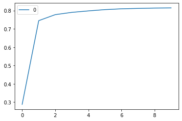

```python
model_loss = pd.DataFrame(history.history['accuracy'])
model_loss.plot()
```

```python
y_pred = model.predict(X_test)
y_pred = y_pred.argmax(axis = 1)
print(classification_report(y_test.argmax(axis = 1),y_pred))
```

```
              precision    recall  f1-score   support

           0       0.75      0.78      0.77      2806
           1       0.81      0.68      0.74      1673
           2       0.90      0.89      0.89      4742
           3       0.61      0.70      0.65      2044
           4       0.81      0.75      0.78      2214
           5       0.62      0.39      0.48       231
           6       0.62      0.67      0.64      1183
           7       0.67      0.53      0.59      1466
           8       0.57      0.26      0.36       237
           9       0.84      0.60      0.70      1668
          10       0.64      0.72      0.68      1132
          11       0.88      0.87      0.87      2319
          12       0.88      0.78      0.83      2487
```

[output cut: 17 more lines]

```python
y_pred = model.predict(X_train)
y_pred = y_pred.argmax(axis = 1)
print(classification_report(y_train.argmax(axis = 1),y_pred))
```

```
              precision    recall  f1-score   support

           0       0.75      0.79      0.77     11063
           1       0.80      0.67      0.73      6995
           2       0.88      0.89      0.89     18667
           3       0.61      0.69      0.65      8090
           4       0.81      0.74      0.78      9226
           5       0.61      0.44      0.51       932
           6       0.62      0.66      0.64      4579
           7       0.68      0.53      0.60      5752
           8       0.49      0.23      0.31       883
           9       0.83      0.59      0.69      6825
          10       0.62      0.70      0.66      4471
          11       0.88      0.86      0.87      9267
          12       0.88      0.78      0.83      9849
```

[output cut: 17 more lines]

## Using Dropout

Dropout is a regularization method that approximates training a large number of neural networks with different architectures in parallel.

During training, some number of layer outputs are randomly ignored or “dropped out.” This has the effect of making the layer look-like and be treated-like a layer with a different number of nodes and connectivity to the prior layer. In effect, each update to a layer during training is performed with a different “view” of the configured layer.

```python
from tensorflow.keras.layers import Dropout
model = Sequential()
model.add(Input(shape=(28, 28, 1)))
model.add(Flatten())
model.add(Dense(50, activation='relu'))
model.add(Dropout(0.1))
model.add(Dense(40, activation='relu'))
model.add(Dropout(0.1))
model.add(Dense(30, activation='relu'))
model.add(Dropout(0.1))
model.add(Dense(26, activation='softmax'))
opt = tf.keras.optimizers.Adam()
model.compile(loss='mean_squared_error', optimizer=opt, metrics=['accuracy', Recall, Precision, F1])
```

```python
history = model.fit(X_train, y_train, epochs=10, batch_size=32,validation_data=(X_test, y_test))
```

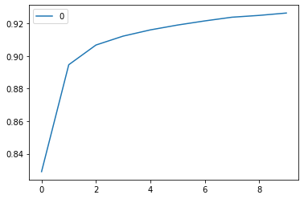

```python
model_loss = pd.DataFrame(history.history['accuracy'])
model_loss.plot()
```

```python
y_pred = model.predict(X_test)
y_pred = y_pred.argmax(axis = 1)
print(classification_report(y_test.argmax(axis = 1),y_pred))
```

```
              precision    recall  f1-score   support

           0       0.92      0.94      0.93      2806
           1       0.95      0.78      0.86      1673
           2       0.89      0.98      0.93      4742
           3       0.97      0.60      0.74      2044
           4       0.88      0.92      0.90      2214
           5       0.79      0.92      0.85       231
           6       0.90      0.78      0.84      1183
           7       0.90      0.88      0.89      1466
           8       0.94      0.81      0.87       237
           9       0.89      0.86      0.87      1668
          10       0.90      0.85      0.88      1132
          11       0.95      0.94      0.95      2319
          12       0.97      0.92      0.94      2487
```

[output cut: 17 more lines]

```python
y_pred = model.predict(X_train)
y_pred = y_pred.argmax(axis = 1)
print(classification_report(y_train.argmax(axis = 1),y_pred))
```

```
              precision    recall  f1-score   support

           0       0.94      0.95      0.95     11063
           1       0.92      0.93      0.92      6995
           2       0.97      0.97      0.97     18667
           3       0.90      0.90      0.90      8090
           4       0.95      0.92      0.94      9226
           5       0.91      0.90      0.91       932
           6       0.92      0.92      0.92      4579
           7       0.93      0.89      0.91      5752
           8       0.95      0.87      0.91       883
           9       0.91      0.93      0.92      6825
          10       0.92      0.88      0.90      4471
          11       0.95      0.97      0.96      9267
          12       0.96      0.95      0.96      9849
```

[output cut: 17 more lines]